# Milestone Report

Leonardo Eras

05/01/2021

## Basic report

```r
#Package tm (Text Mining) required for this assignment.
library(tm)
library(NLP)
library(textmineR)
```

```r
library(RWeka)
library(ggplot2)
library(wordcloud)
```

After downloading and extracting our dataset (be patient, there are a lot of data records), we can start exploring it. This report assumes you donwloaded by your own the datasets We will take some random samples from the files, and not use all of the records. A small sample will suffice for now. This report will include some graphics.

```r
#setwd("/home/leo")
datafolder <- paste(getwd(), "/RstudioProjects/final/en_US/", sep = "")
setwd(datafolder)

#Loading datasets
twitter <- readLines("en_US.twitter.txt", warn = FALSE)
blogs <- readLines("en_US.blogs.txt", warn = FALSE)
news_file <- readLines("en_US.news.txt", warn = FALSE)
```

```r
df <- data.frame(matrix(unlist(l), nrow=length(l), byrow=T))
colnames(df) <- c("file", "size(MB)", "num.of.lines", "longest.line", "num.of.words")
df
```

```
##                                                      file size(MB) num.of.lines
## 1   /home/leo/RstudioProjects/final/en_US/en_US.blogs.txt   200.42       899288
## 2  /home/leo/RstudioProjects/final/en_US/en_US.corpus.txt     1.79        21347
## 3    /home/leo/RstudioProjects/final/en_US/en_US.news.txt   196.28      1010242
## 4  /home/leo/RstudioProjects/final/en_US/en_US.sample.txt     2.73        21347
## 5 /home/leo/RstudioProjects/final/en_US/en_US.twitter.txt   159.36      2360148
##   longest.line num.of.words
## 1       483415     37334131
## 2         3045       281979
## 3       123628     34372530
## 4         3045       506803
## 5           26     30373543
```

After several tests, a random sample of 1% of the data was determined to be enough for this exercise. A larger value will produce an unmanageable corpus.

This is to allow us to provide a faster look at the data to see what we see and decide on the next steps before analyzing the entire data files.

```r
set.seed(1234)

t_sample <- sample(twitter, length(twitter)*.01)
n_sample <- sample(news_file, length(news_file)*0.01)
b_sample <- sample(blogs, length(blogs)*.01)

combined_sample <- c(t_sample, n_sample, b_sample)
combined_sample <- iconv(combined_sample, "UTF-8","ASCII", sub="")
length(combined_sample)
```

```
## [1] 42695
```

In order to create a nanogram, I chose to clean the data a little bit: strip white-space, lower case remove, punctuation remove, number remove, plain text conversion, and english stop-words detection.

```r
corpus <- VCorpus(VectorSource(combined_sample))
corpus <- tm_map(corpus, stripWhitespace)
corpus <- tm_map(corpus, tolower)
corpus <- tm_map(corpus, removePunctuation)
corpus <- tm_map(corpus, removeNumbers)
corpus <- tm_map(corpus, PlainTextDocument)
corpus <- tm_map(corpus, removeWords, stopwords("english"))
```

```r
unigram <- function(x) NGramTokenizer(x, Weka_control(min = 1, max = 1))
unigram_tdm <- TermDocumentMatrix(corpus, control = list(tokenize = unigram))
unigram_freqTerm <- findFreqTerms(unigram_tdm,lowfreq = 40)

bigram <- function(x) NGramTokenizer(x, Weka_control(min = 2, max = 2))
bigram_tdm <- TermDocumentMatrix(corpus, control = list(tokenize = bigram))
bigram_freqTerm <- findFreqTerms(bigram_tdm,lowfreq=40)

trigram <- function(x) NGramTokenizer(x, Weka_control(min = 3, max = 3))
trigram_tdm <- TermDocumentMatrix(corpus, control = list(tokenize = trigram))
trigram_freqTerm <- findFreqTerms(trigram_tdm,lowfreq=10)

quadgram <- function(x) NGramTokenizer(x, Weka_control(min = 4, max = 4))
quadgram_tdm <- TermDocumentMatrix(corpus, control = list(tokenize = quadgram))
quadgram_freqTerm <- findFreqTerms(quadgram_tdm,lowfreq=10)
```

## Unigram word cloud and histogram

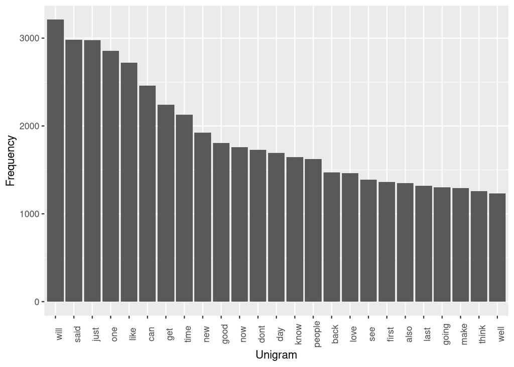

```r
unigram_freq <- rowSums(as.matrix(unigram_tdm[unigram_freqTerm,]))
unigram_ord <- order(unigram_freq, decreasing = TRUE)
unigram_freq <- data.frame(word=names(unigram_freq[unigram_ord]), frequency=unigram_freq[unigram_ord])

ggplot(unigram_freq[1:25,], aes(factor(word, levels = unique(word)), frequency)) +
  geom_bar(stat = 'identity')+
  theme(axis.text.x=element_text(angle=90))+
  xlab('Unigram')+
  ylab('Frequency')
```

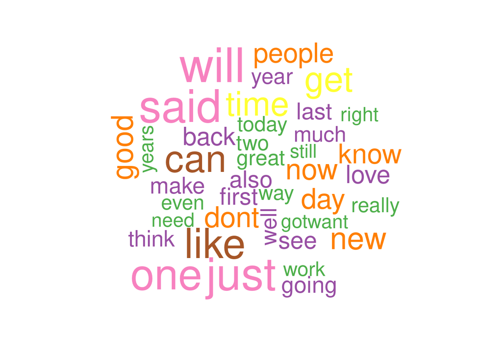

```r
wordcloud(unigram_freq$word, unigram_freq$frequency, max.words=40, colors=brewer.pal(8, "Set1"))
```

Now with our constructed bigram

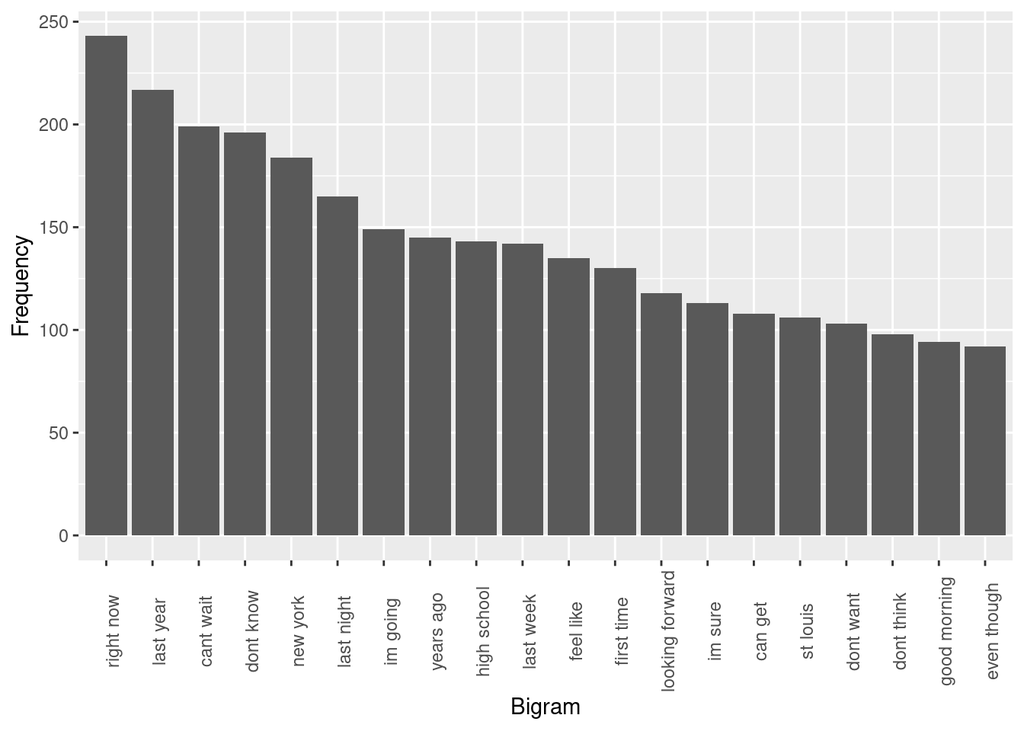

```r
bigram_freq <- rowSums(as.matrix(bigram_tdm[bigram_freqTerm,]))
bigram_ord <- order(bigram_freq, decreasing = TRUE)
bigram_freq <- data.frame(word=names(bigram_freq[bigram_ord]), frequency=bigram_freq[bigram_ord])

ggplot(bigram_freq[1:20,], aes(factor(word, levels = unique(word)), frequency)) +
  geom_bar(stat = 'identity')+
  theme(axis.text.x=element_text(angle=90))+
  xlab('Bigram')+
  ylab('Frequency')
```

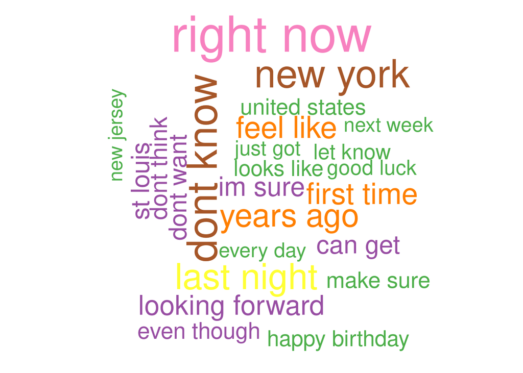

```r
wordcloud(bigram_freq$word, bigram_freq$frequency, max.words=30, colors=brewer.pal(8, "Set1"))
```

With the trigram

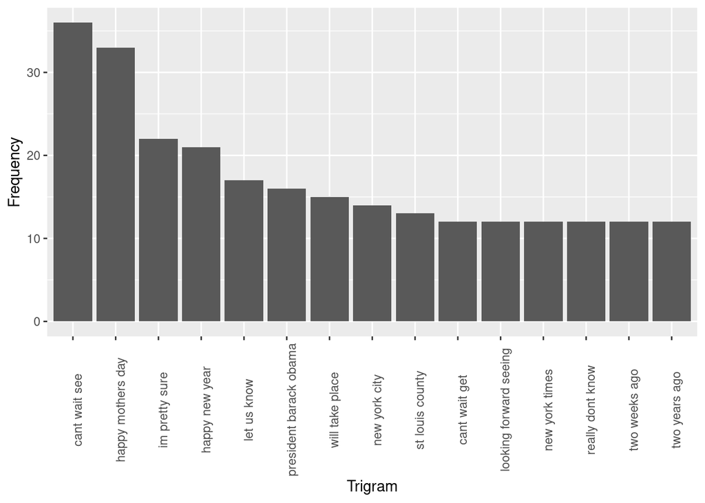

```r
trigram_freq <- rowSums(as.matrix(trigram_tdm[trigram_freqTerm,]))
trigram_ord <- order(trigram_freq, decreasing = TRUE)
trigram_freq <- data.frame(word=names(trigram_freq[trigram_ord]), frequency=trigram_freq[trigram_ord])

ggplot(trigram_freq[1:15,], aes(factor(word, levels = unique(word)), frequency)) +
  geom_bar(stat = 'identity')+
  theme(axis.text.x=element_text(angle=90))+
  xlab('Trigram')+
  ylab('Frequency')
```

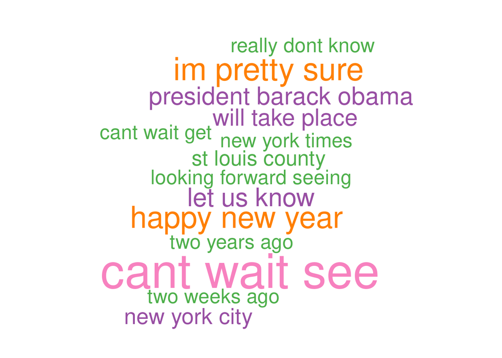

```r
wordcloud(trigram_freq$word, trigram_freq$frequency, max.words=15, colors=brewer.pal(8, "Set1"))
```